# Did they hold the hand rail?!

STATS 220 Semester One 2026

Zhi Sheng

2026-05-12

## My data

My data is to explore the pattern of whether people hold the handrail when they use stairs.

I collected the group size data: this is to see when people walk on stairs in groups, whether there’s any pattern on handrail holding.

There’s also data on whether people’s hands are empty and how that affects the handrail holding.

A new piece of data I collected this time is whether the observed sample wears high heels or not. It is common belief that high heels aren’t stable for walking, especially on the stairs. So I assumed people would hold the hand rials more often when they are in high heels. We will see if that assumption is true!

Lastly, I collected 34 more observation points. When I was creating the visuals, I excluded the previous data collection as the new attributes would be blank for those data.

This page can be found from [here](https://situdaman.github.io/Project2/visual_data_story.html).

[figure not shown]

## Does group size affect rail holding

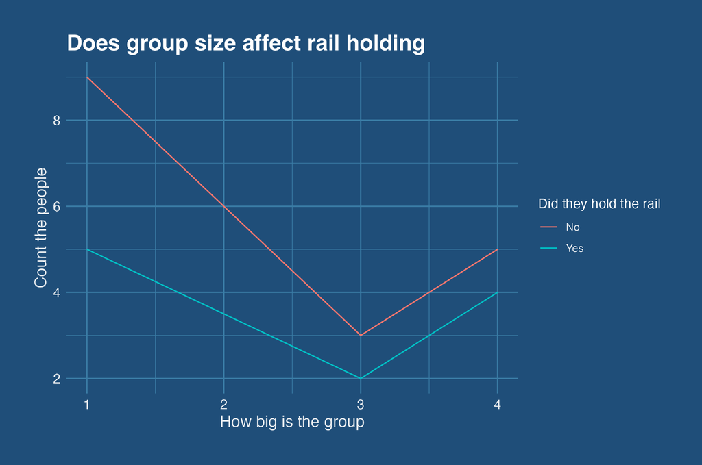

A line chart showing how rail holding pattern chaing with group size

I summarized the data collected to show the numbers of people holding or not holding the hand rails considering their group size. I wanted to see if the group size affect the pattern. The patterns are very similar however I can’t find any causes to explain this - it could be just luck.

## Does the empty hand hold the rail

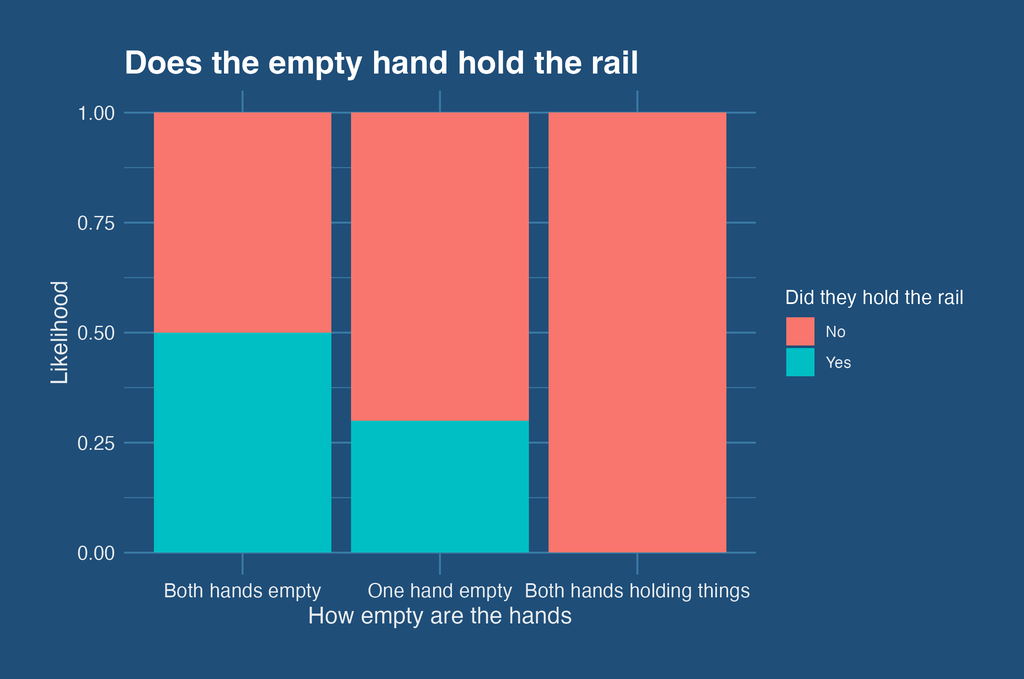

a stacked bar chart comparing the ratio of people holding hand rail when their hands are occupied, or not

The data is summarized to see the ratio of people holding hand rail, when their hands are occupied, or not. When both hands are holding things, of course they can’t be holding the hand rail at the same time. When one hand is full, it gets less likely for people to hold the hand rail - maybe people is simply preoccupied when there’s something in their hands!

## Are they confident with high heels

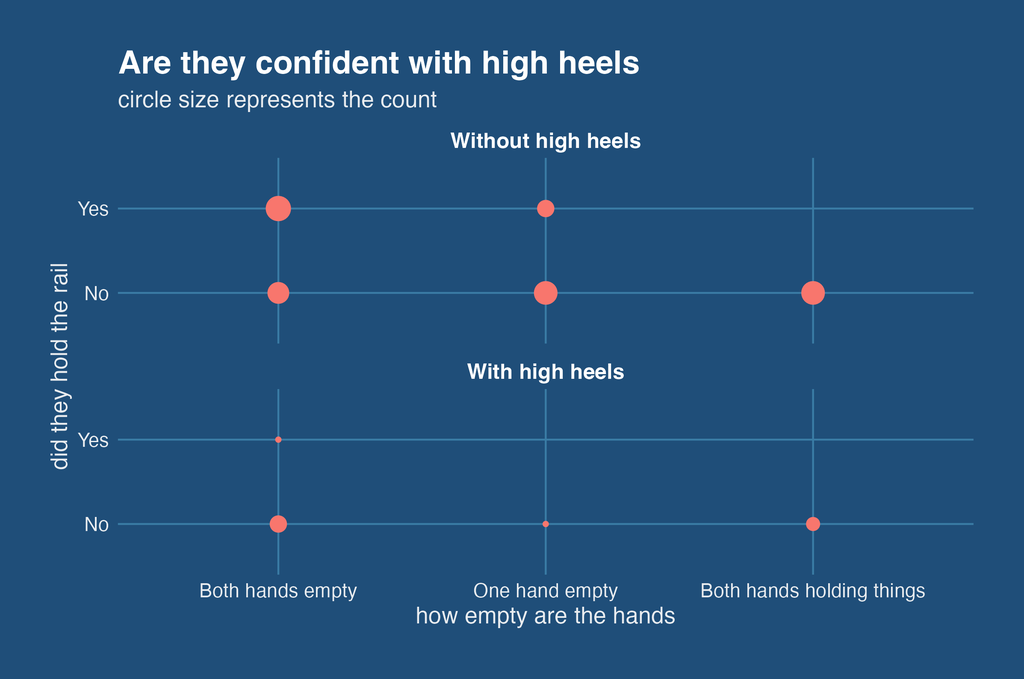

a faceted count chart comparing the results from people wearing high heels (or not)

Interesting to see most of the observed samples don’t hold hand rails when they are in high heels! But, as a man, what do I know about walking in high heels.

## How fast did I log the observation

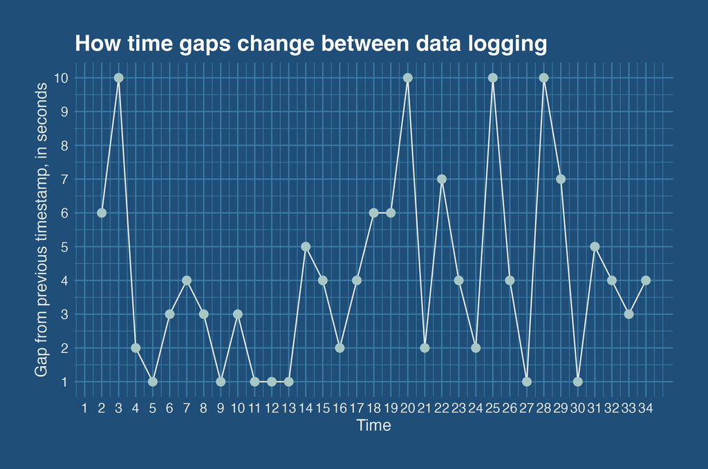

Since I did my observation at work, I logged all my observation using my Google Form. There are only 4 questions and I thought I can get faster and faster each time I entered the data. However, after some initial improvement, I must have got tired with my fingers or just bored, the gap between each data entry started to fluctuate and stayed on the higher side. Sometimes I made a mistake and the correction took my time, hence those 10-second gaps!

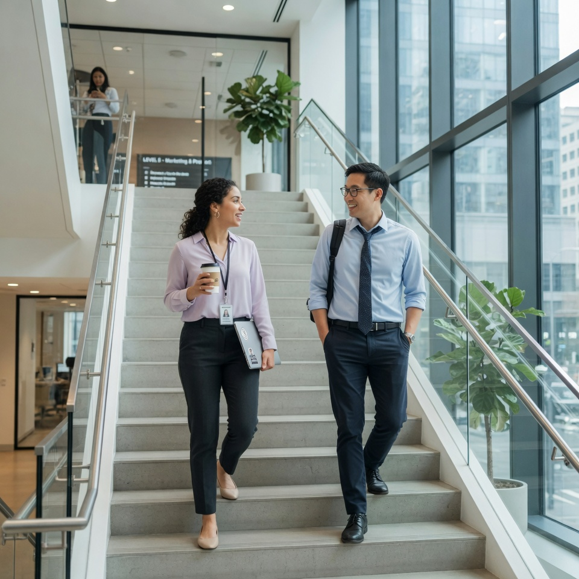